# Lab9_Rust

Elise Rust

11/1/2021

```r
library(tidyverse)
```

```r
library(ggplot2)
library(boot)
library(ISLR)
library(plotrix)
```

# Problem #1:

```r
bdesh <- read.csv("Bangladesh.csv")
head(bdesh)
```

```
##   Arsenic Chlorine Cobalt
## 1    2400      6.2   0.42
## 2       6    116.0   0.45
## 3     904     14.8   0.63
## 4     321     35.9   0.68
## 5    1280     18.9   0.58
## 6     151      7.8   0.35
```

1. Plot the boxplot of Cobalt. What looks wrong? Do you think a transformation can explain the data better?

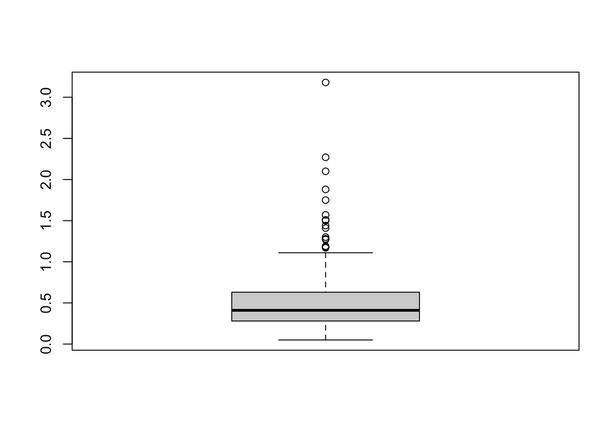

```r
boxplot(bdesh$Cobalt)
```

There are many many outliers in this dataset - hence the number of points beyond the IQR of the boxplot. A log transformation may help us analyze the data better.

2. Make a log transformation of the data (Cobalt) and plot the boxplot. What do you see differently? Comment.

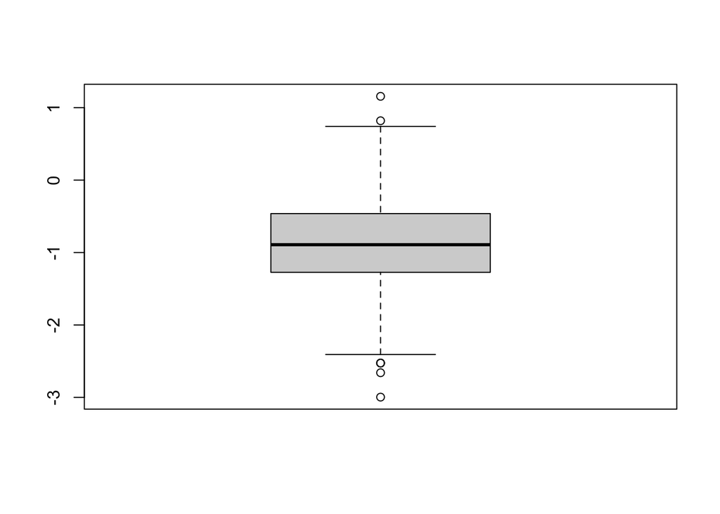

```r
bdesh$Cobalt_log = log(bdesh$Cobalt)
boxplot(bdesh$Cobalt_log)
```

Now, the majority of the data is contained within the IQR (way fewer outliers) and the data is more normally distributed.

3. Are there an missing values? If so, remove the missing values and draw bootstrap samples(10000) of sample mean. (remeber we are still using the log transformation)

```r
is.na(bdesh$Cobalt) # Yes there are null values
```

[output not shown]

```r
bdesh <- na.omit(bdesh) # Remove rows with "NA"s

# Draw bootstrap samples
n <- length(bdesh$Cobalt_log)
N <- 10000
cobalt.mean <- numeric(N)

for (i in 1:N) {
  x <- sample(bdesh$Cobalt_log, n, replace = TRUE)
  cobalt.mean[i] <- mean(x) #bootstrap sample mean
}

head(cobalt.mean)
```

```
## [1] -0.9971340 -0.9488953 -0.9050249 -0.8518810 -0.9120798 -0.8775030
```

4. What is the bias?

```r
cobalt_mean = mean(bdesh$Cobalt_log)
bootstrap_mean = mean(cobalt.mean)

bias = cobalt_mean - bootstrap_mean

cat("The bias is: ", bias, " meaning that the estimate tends to underestimate the true mean.")
```

```
## The bias is:  0.0005416442  meaning that the estimate tends to underestimate the true mean.
```

5. Find the standard error of the bootstrap estimate.

```r
cat("The standard error of the bootstrap sample is: ", std.error(cobalt.mean))
```

```
## The standard error of the bootstrap sample is:  0.0004038364
```

Also, calculate the estimate(using the bootstrap sample) of mean squared error(MSE) =var(X)+ (bias)ˆ2 Comment on your results.

```r
VAR = var(cobalt.mean)
print(VAR)
```

```
## [1] 0.001630839
```

```r
print(bias)
```

```
## [1] 0.0005416442
```

```r
MSE = VAR + bias^2
cat("The mean squared error (MSE) - calculated using the boostrap sample - is: ", MSE)
```

```
## The mean squared error (MSE) - calculated using the boostrap sample - is:  0.001631132
```

6. Make a 95% Percentile Bootstrap CI for mean of log transformed(log10) Cobalt data. Comment on your results.

```r
quantile(cobalt.mean, c(0.025, 0.975))
```

```
##       2.5%      97.5%
## -0.9800894 -0.8199306
```

7. Repeat the bootstrap sampling process to estimate the median of the actual data(Cobalt- no transformation).

```r
n <- length(bdesh$Cobalt)
N <- 10000
cobalt.median <- numeric(N)

for (i in 1:N) {
  x <- sample(bdesh$Cobalt, n, replace = TRUE)
  cobalt.median[i] <- median(x) #bootstrap sample mean
}

head(cobalt.median)
```

```
## [1] 0.420 0.415 0.390 0.410 0.415 0.390
```

```r
cat("The median of the actual data is estimated to be: ", median(cobalt.median), " via estimation using the boostrap sampling process. The medians are the same - indicating that the bootstrap sampling provides a good estimation of the actual data.")
```

```
## The median of the actual data is estimated to be:  0.41  via estimation using the boostrap sampling process. The medians are the same - indicating that the bootstrap sampling provides a good estimation of the actual data.
```

```r
# Find the bias
cobalt_median = median(bdesh$Cobalt)
bootstrap_median = median(cobalt.median)

bias2 = cobalt_median - bootstrap_median

cat("The bias is: ", bias2, " meaning that the estimate provides an accurate estimation of the true median value of the dataset.")
```

```
## The bias is:  0  meaning that the estimate provides an accurate estimation of the true median value of the dataset.
```

```r
# Find standard error
cat("The standard error of the bootstrap sample is: ", std.error(cobalt.median))
```

```
## The standard error of the bootstrap sample is:  0.0001537986
```

# Problem #2:

```r
Titanic = read.csv("Titanic.csv",stringsAsFactors=FALSE)
head(Titanic)
```

```
##   ID Survived   Age
## 1  1        1  0.92
## 2  2        0 30.00
## 3  3        1 48.00
## 4  4        0 39.00
## 5  5        0 71.00
## 6  6        0 47.00
```

1. First let’s seperate the two samples “survivors(=1)” and “victims(=0)”.

```r
titanic.survived <- Titanic$Age[Titanic$Survived == 1]
titanic.victims <- Titanic$Age[Titanic$Survived == 0]
```

2. Make many bootstrap samples(100000) of difference of sample means.

```r
titanic_bootstrap <- rep(NA,100000)

for (j in 1:100000) {
  boot.survived <- mean(sample(titanic.survived, length(titanic.survived), replace = T))
  boot.victims <- mean(sample(titanic.victims, length(titanic.victims), replace = T))
  titanic_bootstrap[j] <- boot.survived - boot.victims #the difference
}

head(titanic_bootstrap)
```

```
## [1] -3.080848 -2.539994 -4.631791 -4.689378 -3.932018 -2.437987
```

```r
mean(titanic_bootstrap) #bootstrap mean difference
```

```
## [1] -4.54109
```

3. Make a 90% percentile bootstrap confidence interval for the difference estimate. Using this CI, conclude on your hypothesis.

```r
CI <- quantile(titanic_bootstrap, c(.05, .95))
CI
```

```
##        5%       95%
## -6.964836 -2.116071
```

Null Hypothesis: Mean ages of survivors and of victims are the same. (That means that there is no difference between the two population means)

The null value of 0 is not inside the confidence interval; thereforec we reject the null hypothesis and conclude that there is a statistically significant difference in ages of survivors and victims at the 10% level.

4. Make a 95% percentile bootstrap confidence interval for the difference estimate and using this CI, conclude on your hypothesis.

```r
CI2 <- quantile(titanic_bootstrap, c(.025, .975))
CI2
```

```
##      2.5%     97.5%
## -7.408989 -1.668271
```

Null Hypothesis: Mean ages of survivors and of victims are the same. (That means that there is no difference between the two population means)

The null value of 0 is not inside the confidence interval; thereforec we reject the null hypothesis and conclude that there is a statistically significant difference in ages of survivors and victims at the 5% level.